# Metabolomic Analysis

Emily Bean

January 10, 2020

# Overview

This is the preliminary data analysis for the 15-02 metabolomics dataset, Dr. Connie Rogers lab.

## General cleaning steps

1. Download archived raw .wiff files from Metabolomics Core
2. Convert .wiff to .mzML in ProteoWizard 4.0 (MS Convert)
3. Peak picking and alignment in MSDIAL (MoNA database for hydrophilic; LipidBlast for lipids)
4. Tidy in Excel
5. Upload to MetaboAnalyst; quantile normalization, Pareto scaling, and log transformation
6. Download normalized data for statistical analysis in R

## Analysis Steps

1. Individual metabolites (THIS SCRIPT)
2. Sample clustering
3. Metabolic “community” (`metabolomicsNMDS.Rmd`)

# Pairwise comparisons

*All comparisons made for both tumor and plasma tissues*

1. Plasma vs tumor
2. Plasma D7 vs D21 vd D35
3. 4 treatment groups (2x2 factorial)
4. Exercise vs sedentary
5. Weight gain vs weight maintenance

**Note:** These are *annotated metabolites only*. In the raw dataset are many tens of thousands more metabolites and lipids that were detected as compounds but not annotated; we can do a community analysis on these later if we want to.

**Note: in pairwise comparions, the data has been normalized, scaled, and log-transformed in MetaboAnalyst. An accompanying PDF report describes those steps.**

## Plasma vs tumor

We would assume that the plasma and tumor tissue would differ significantly in their metabolic makeup, so this is really more of a “double-check” than an an analysis.

| metabolite | fStat | contrast | estimate | SE | df | t.ratio | p.value |
| --- | --- | --- | --- | --- | --- | --- | --- |
| Pyruvate | 84.6312 | plasma - tumor | 2.1756211 | 0.236 | 83 | 9.200 | 0.000 |
| X2.Oxobutanoate | 17.6320 | plasma - tumor | 1.2224319 | 0.291 | 83 | 4.199 | 0.000 |
| Acetoacetate | 30.9197 | plasma - tumor | 1.4925135 | 0.268 | 83 | 5.561 | 0.000 |
| X3.Hydroxybutyric.acid | 26.1005 | plasma - tumor | 1.4561872 | 0.285 | 83 | 5.109 | 0.000 |
| Serine | 23.6487 | plasma - tumor | 1.1245657 | 0.231 | 83 | 4.863 | 0.000 |
| Glycerate | 49.0897 | plasma - tumor | 1.4720622 | 0.210 | 83 | 7.006 | 0.000 |
| Uracil | 57.6070 | plasma - tumor | 2.5059812 | 0.330 | 83 | 7.590 | 0.000 |
| Proline | 4.4720 | plasma - tumor | -0.3912437 | 0.185 | 83 | -2.115 | 0.037 |
| Maleic.acid | 54.3404 | plasma - tumor | -1.9180123 | 0.260 | 83 | -7.372 | 0.000 |
| Fumarate | 65.8562 | plasma - tumor | -1.5942845 | 0.196 | 83 | -8.115 | 0.000 |
| X2.Keto.isovalerate | 57.8577 | plasma - tumor | 2.2291250 | 0.293 | 83 | 7.606 | 0.000 |
| Acetyl.glycine | 91.6729 | plasma - tumor | 1.9391102 | 0.203 | 83 | 9.575 | 0.000 |
| Valine.5.Aminopentanoic.acid | 4.1041 | plasma - tumor | 0.4245551 | 0.210 | 83 | 2.026 | 0.046 |
| Succinate.Methylmalonic.acid | 73.8988 | plasma - tumor | 1.7670370 | 0.206 | 83 | 8.596 | 0.000 |
| Threonine.Homoserine | 24.4890 | plasma - tumor | 1.2807129 | 0.259 | 83 | 4.949 | 0.000 |
| Cysteine | 5.5153 | plasma - tumor | -0.6359956 | 0.271 | 83 | -2.348 | 0.021 |
| Nicotinate | 5.7519 | plasma - tumor | -0.5376586 | 0.224 | 83 | -2.398 | 0.019 |
| Pyroglutamic.acid | 8.6334 | plasma - tumor | -1.0313070 | 0.351 | 83 | -2.938 | 0.004 |
| Pipecolic.Acid | 103.7634 | plasma - tumor | 1.9241235 | 0.189 | 83 | 10.186 | 0.000 |
| Citraconic.acid | 21.9291 | plasma - tumor | 1.2935344 | 0.276 | 83 | 4.683 | 0.000 |
| Ketoleucine | 28.7654 | plasma - tumor | 1.4455064 | 0.270 | 83 | 5.363 | 0.000 |
| Hydroxyproline.Aminolevulinate | 7.5134 | plasma - tumor | 0.5323683 | 0.194 | 83 | 2.741 | 0.007 |
| N.Acetyl.L.alanine | 241.9866 | plasma - tumor | -2.3668851 | 0.152 | 83 | -15.556 | 0.000 |
| Leucine.Isoleucine | 8.8679 | plasma - tumor | -0.6447746 | 0.217 | 83 | -2.978 | 0.004 |
| Hydroxyisocaproic.acid | 113.8077 | plasma - tumor | 1.9374116 | 0.182 | 83 | 10.668 | 0.000 |
| Ornithine | 10.3017 | plasma - tumor | -0.6940121 | 0.216 | 83 | -3.210 | 0.002 |
| Malate | 28.9172 | plasma - tumor | -1.7607439 | 0.327 | 83 | -5.377 | 0.000 |
| Homocysteine.Methylcysteine | 177.3645 | plasma - tumor | 2.3928676 | 0.180 | 83 | 13.318 | 0.000 |
| Anthranilate | 70.5886 | plasma - tumor | 2.3770995 | 0.283 | 83 | 8.402 | 0.000 |
| Acetylphosphate | 34.7000 | plasma - tumor | 1.4084792 | 0.239 | 83 | 5.891 | 0.000 |

[output cut: 83 more lines]

| metabolite | Plasma mean | Tumor mean |
| --- | --- | --- |
| Acetoacetate | 0.369 | -1.124 |
| Acetyl.aspartate | -0.424 | 1.292 |
| Acetyl.glycine | 0.479 | -1.460 |
| Acetyllysine | 0.447 | -1.361 |
| Acetylphosphate | 0.348 | -1.061 |
| Aconitate | 0.338 | -1.031 |
| ADP | -0.604 | 1.840 |
| ADP.D.glucose | -0.643 | 1.960 |
| Allantoate | 0.621 | -1.893 |
| Alpha.ketoglutarate | 0.685 | -2.087 |
| Anthranilate | 0.587 | -1.790 |
| Arginine | 0.407 | -1.241 |
| Ascorbic.acid | -0.824 | 2.512 |
| CDP | 0.202 | -0.614 |
| CDP.choline | -0.420 | 1.280 |
| CDP.ethanolamine | -0.780 | 2.378 |
| Chlorpropamide | 0.430 | -1.311 |
| Citraconic.acid | 0.320 | -0.974 |
| Citrulline | 0.641 | -1.954 |
| CMP | -0.277 | 0.844 |
| Cyclic.AMP | 0.316 | -0.962 |
| Cystathionine | 0.572 | -1.744 |
| Cysteine | -0.157 | 0.479 |
| D.Sedoheptulose.1.7.phosphate | -0.805 | 2.453 |
| dAMP | -0.730 | 2.224 |
| dCMP | -0.771 | 2.351 |
| Deoxyribose.phosphate | -0.530 | 1.615 |
| Deoxyuridine | 0.415 | -1.264 |
| Dihydroxy.acetone.phosphate | -0.649 | 1.977 |
| dTMP | -0.624 | 1.903 |

[output cut: 83 more lines]

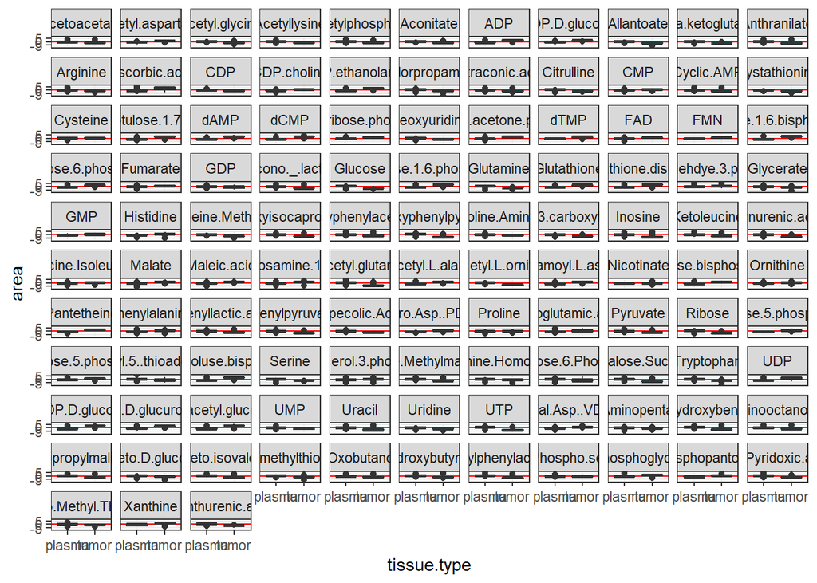

## Plasma D7 vs D21 v D35

It’s important for downstream analysis to first determine if the plasma metabolome change significantly from day 7, to day 21, to day 35. If there are differences, we will need to keep the days separate for downstream analyses; if not, we can likely lump them all together.

|  | metabolite | fStat | contrast | estimate | SE | df | t.ratio | p.value |
| --- | --- | --- | --- | --- | --- | --- | --- | --- |
| 3 | Pyruvate | 4.4106 | 21 - 35 | 0.6697998 | 0.240 | 61 | 2.795 | 0.019 |
| 2 | Alanine.Sacrosine | 10.4145 | 7 - 35 | -1.0678839 | 0.240 | 61 | -4.448 | 0.000 |
| 31 | Alanine.Sacrosine | 10.4145 | 21 - 35 | -0.7226311 | 0.247 | 61 | -2.929 | 0.013 |
| 21 | X3.Hydroxybutyric.acid | 4.1937 | 7 - 35 | 0.5896581 | 0.220 | 61 | 2.676 | 0.026 |
| 22 | Serine | 4.9959 | 7 - 35 | -0.8654239 | 0.274 | 61 | -3.161 | 0.007 |
| 32 | Uracil | 3.9600 | 21 - 35 | 0.4981557 | 0.194 | 61 | 2.568 | 0.033 |
| 23 | Threonine.Homoserine | 3.4246 | 7 - 35 | -0.7231883 | 0.277 | 61 | -2.615 | 0.030 |
| 1 | Nicotinate | 4.1435 | 7 - 21 | 0.6612875 | 0.248 | 61 | 2.663 | 0.026 |
| 33 | Taurine | 4.7403 | 21 - 35 | -0.6816608 | 0.242 | 61 | -2.816 | 0.018 |
| 24 | Citraconic.acid | 4.5520 | 7 - 35 | 0.6904726 | 0.266 | 61 | 2.598 | 0.031 |
| 34 | Citraconic.acid | 4.5520 | 21 - 35 | 0.6954141 | 0.273 | 61 | 2.546 | 0.035 |
| 25 | N.Acetyl.L.alanine | 5.5883 | 7 - 35 | -0.4460298 | 0.141 | 61 | -3.156 | 0.007 |
| 35 | N.Acetyl.L.alanine | 5.5883 | 21 - 35 | -0.3510132 | 0.145 | 61 | -2.416 | 0.048 |
| 26 | Leucine.Isoleucine | 2.9362 | 7 - 35 | -0.5088675 | 0.211 | 61 | -2.414 | 0.049 |
| 27 | Asparagine | 5.8338 | 7 - 35 | -0.9701278 | 0.284 | 61 | -3.414 | 0.003 |
| 28 | Homocysteine.Methylcysteine | 3.3303 | 7 - 35 | -0.4534735 | 0.178 | 61 | -2.547 | 0.035 |
| 29 | Anthranilate | 4.2432 | 7 - 35 | 0.4842139 | 0.196 | 61 | 2.465 | 0.043 |
| 36 | Anthranilate | 4.2432 | 21 - 35 | 0.5053494 | 0.202 | 61 | 2.503 | 0.039 |
| 210 | Methionine | 5.6469 | 7 - 35 | -0.6549913 | 0.216 | 61 | -3.029 | 0.010 |
| 37 | Methionine | 5.6469 | 21 - 35 | -0.5940153 | 0.222 | 61 | -2.673 | 0.026 |
| 211 | X2.Aminooctanoic.acid | 4.8766 | 7 - 35 | 0.7652508 | 0.275 | 61 | 2.781 | 0.019 |
| 38 | X2.Aminooctanoic.acid | 4.8766 | 21 - 35 | 0.7152616 | 0.283 | 61 | 2.529 | 0.037 |
| 39 | sn.Glycerol.3.phosphate | 3.9258 | 21 - 35 | -0.7449903 | 0.269 | 61 | -2.768 | 0.020 |
| 212 | Pantothenate | 8.0261 | 7 - 35 | -0.3263773 | 0.089 | 61 | -3.677 | 0.001 |
| 310 | Pantothenate | 8.0261 | 21 - 35 | -0.2817081 | 0.091 | 61 | -3.088 | 0.008 |
| 213 | Deoxyuridine | 6.3882 | 7 - 35 | -0.8914101 | 0.256 | 61 | -3.485 | 0.003 |
| 214 | Pro.Asp..PD. | 4.7172 | 7 - 35 | -0.6129009 | 0.206 | 61 | -2.972 | 0.012 |
| 215 | Uridine | 3.9704 | 7 - 35 | -0.5843259 | 0.218 | 61 | -2.686 | 0.025 |
| 11 | Xanthosine | 8.5599 | 7 - 21 | 1.3647889 | 0.330 | 61 | 4.138 | 0.000 |
| 216 | AMP | 3.2634 | 7 - 35 | 1.0809500 | 0.442 | 61 | 2.444 | 0.045 |
| 12 | FMN | 4.9084 | 7 - 21 | -0.9535323 | 0.325 | 61 | -2.936 | 0.013 |
| 217 | FMN | 4.9084 | 7 - 35 | -0.7422961 | 0.306 | 61 | -2.422 | 0.048 |
| 311 | UDP.N.acetyl.glucosamine | 3.0304 | 21 - 35 | -0.6981961 | 0.286 | 61 | -2.441 | 0.046 |

Another visualization tool is boxplots.

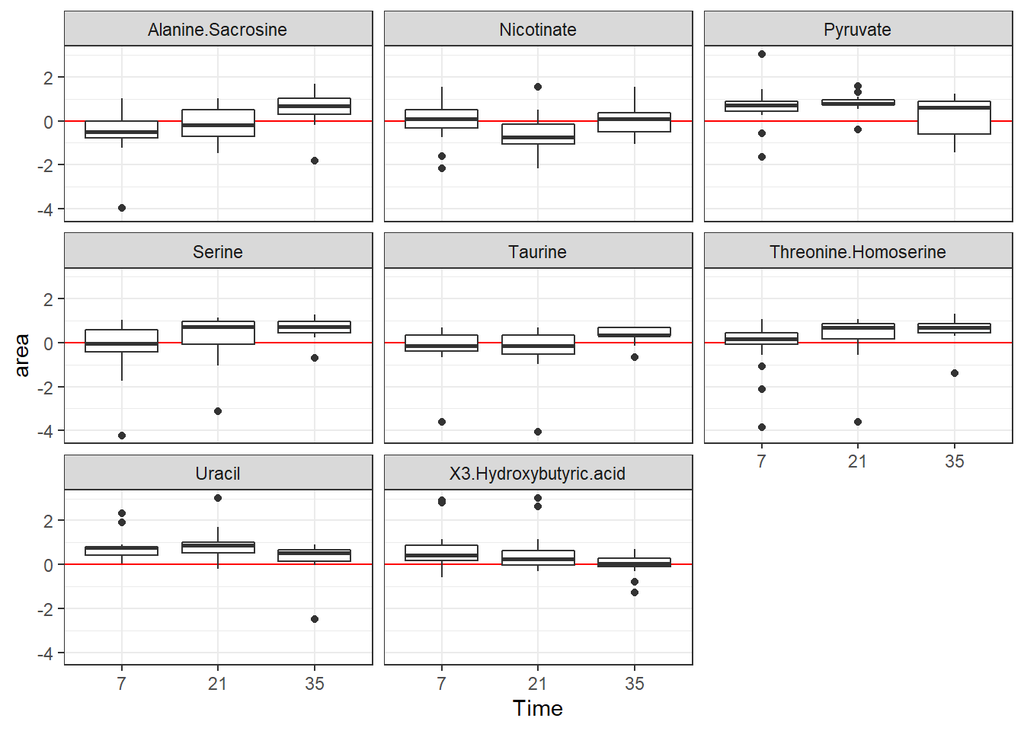

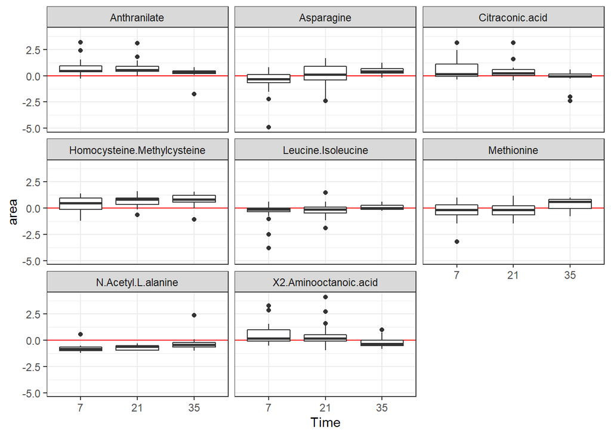

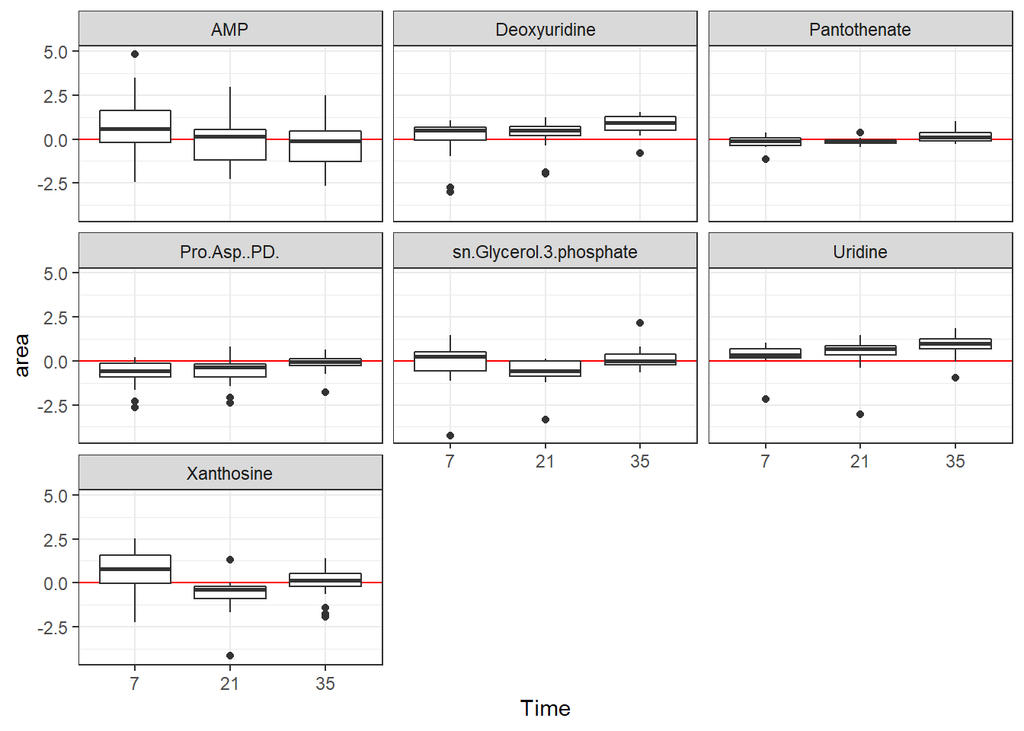

An ANOVA on each individual metabolite by Time shows that there are multiple metabolites that differ between the times, so when analyzing plasma metabolome we will keep Time as a separate factor. The Tukey tests indicate that most metabolites differ between either D7 and D35, or D21 and D35. Few (or none) indicate difference between D7 and D21. This should be explored further to examine if the differences are due to cancer development or if they can be attributed to other things like growth and metabolism.

## Four treatment groups

The initial analyis is comparing all four treatment groups to each other in the 2x2 factorial style. The code follows this structure for pairwise comparisons with ANOVA:

> This code is a one-way ANOVA between the log-transformed area under the curve (dependent variable) and the four treatment groups (independent variable) for the tumor tissue only. This ANOVA repeats in a “for loop” for all 136 aqueous metabolites, and stores the p values in a table.

### Tumor tissue

There are four significant metabolites; that is, four metabolites vary significantly between the four treatment groups in the tumor tissue.

|  | metabolite | fStat | contrast | estimate | SE | df | t.ratio | p.value |
| --- | --- | --- | --- | --- | --- | --- | --- | --- |
| 1 | Hydroxyproline.Aminolevulinate | 4.3665 | EX_AL - EX_ER | 1.2602894 | 0.353 | 17 | 3.573 | 0.011 |
| 4 | Quinolinate | 6.0403 | EX_ER - SED_AL | -3.0450679 | 0.741 | 17 | -4.107 | 0.004 |
| 6 | Quinolinate | 6.0403 | SED_AL - SED_ER | 2.0493143 | 0.707 | 17 | 2.899 | 0.045 |
| 3 | Acetyl.aspartate | 4.2735 | EX_AL - SED_ER | -1.3497777 | 0.384 | 17 | -3.512 | 0.013 |
| 11 | Glucose | 5.6869 | EX_AL - EX_ER | 0.7631781 | 0.225 | 17 | 3.395 | 0.016 |
| 41 | Glucose | 5.6869 | EX_ER - SED_AL | -0.6969954 | 0.203 | 17 | -3.435 | 0.015 |

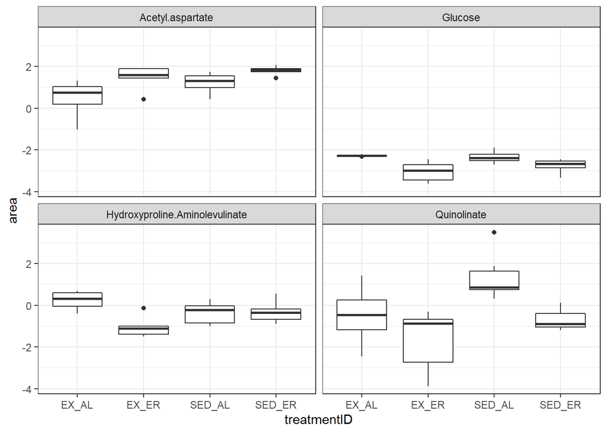

Quinolinate and Glucose both vary between two different treatments, which is why they are listed twice. It is important to note that dividing the data into four treatment groups rather than two (e.g. Exercise vs Sedentary) decreases the number of mice in each group, which is likely why there are fewer metabolites that are significant when comparing all 4 groups.

### Plasma

Since we clearly saw that there is a difference in the plasma aqueous metabolites between days (above), we will keep Time as a separate factor moving forward. Therefore, there are 3 separate ANOVAs performed for each test; one for each time point. The results of each time point are independent of the others.

|  | metabolite | Time | fStat | contrast | estimate | SE | df | t.ratio | p.value |
| --- | --- | --- | --- | --- | --- | --- | --- | --- | --- |
| 8 | Pyruvate | D21 | 3.2470 | EX_AL - SED_AL | -0.7254571 | 0.239 | 15 | -3.032 | 0.038 |
| 7 | Alanine.Sacrosine | D21 | 4.0877 | EX_AL - EX_ER | 1.2470241 | 0.420 | 15 | 2.969 | 0.042 |
| 10 | Alanine.Sacrosine | D21 | 4.0877 | EX_ER - SED_AL | -1.0152247 | 0.348 | 15 | -2.915 | 0.047 |
| 71 | Maleic.acid | D21 | 4.6255 | EX_AL - EX_ER | -1.1634300 | 0.347 | 15 | -3.354 | 0.020 |
| 101 | Maleic.acid | D21 | 4.6255 | EX_ER - SED_AL | 0.8502497 | 0.288 | 15 | 2.956 | 0.044 |
| 16 | Acetyl.glycine | D35 | 4.2367 | EX_ER - SED_AL | -1.1828718 | 0.358 | 20 | -3.304 | 0.017 |
| 18 | Cysteine | D35 | 4.0303 | SED_AL - SED_ER | 1.5530875 | 0.475 | 20 | 3.268 | 0.019 |
| 1 | Pipecolic.Acid | D7 | 3.5575 | EX_AL - EX_ER | 0.8698665 | 0.290 | 17 | 2.998 | 0.037 |
| 72 | Leucine.Isoleucine | D21 | 3.6967 | EX_AL - EX_ER | 1.2429097 | 0.416 | 15 | 2.988 | 0.041 |
| 81 | Leucine.Isoleucine | D21 | 3.6967 | EX_AL - SED_AL | 1.1655654 | 0.403 | 15 | 2.893 | 0.049 |
| 11 | Lysine | D7 | 4.0390 | EX_AL - EX_ER | 1.5322530 | 0.453 | 17 | 3.385 | 0.017 |
| 73 | X2.Oxo.4.methylthiobutanoate | D21 | 4.9911 | EX_AL - EX_ER | 1.5506033 | 0.444 | 15 | 3.493 | 0.015 |
| 9 | X2.Oxo.4.methylthiobutanoate | D21 | 4.9911 | EX_AL - SED_ER | 1.3119577 | 0.444 | 15 | 2.955 | 0.044 |
| 111 | Ribose | D21 | 3.5104 | EX_ER - SED_ER | -0.8152667 | 0.267 | 15 | -3.052 | 0.036 |
| 17 | Xanthine | D35 | 5.1733 | EX_ER - SED_ER | -2.0934440 | 0.662 | 20 | -3.161 | 0.023 |
| 181 | Xanthine | D35 | 5.1733 | SED_AL - SED_ER | -2.3271391 | 0.687 | 20 | -3.386 | 0.014 |
| 171 | Phenyllactic.acid | D35 | 3.3543 | EX_ER - SED_ER | 1.2189198 | 0.389 | 20 | 3.132 | 0.025 |
| 74 | Quinolinate | D21 | 6.6892 | EX_AL - EX_ER | -1.3830950 | 0.434 | 15 | -3.185 | 0.028 |
| 112 | Quinolinate | D21 | 6.6892 | EX_ER - SED_ER | 1.5478056 | 0.376 | 15 | 4.116 | 0.005 |
| 75 | Dihydroxy.acetone.phosphate | D21 | 3.0268 | EX_AL - EX_ER | -1.0099896 | 0.348 | 15 | -2.901 | 0.048 |
| 76 | Glucose | D21 | 4.6525 | EX_AL - EX_ER | 1.0251641 | 0.354 | 15 | 2.893 | 0.049 |
| 102 | Glucose | D21 | 4.6525 | EX_ER - SED_AL | -0.8603491 | 0.294 | 15 | -2.928 | 0.046 |
| 113 | Glucose | D21 | 4.6525 | EX_ER - SED_ER | -0.9708401 | 0.307 | 15 | -3.164 | 0.029 |
| 103 | X4.Pyridoxic.acid | D21 | 3.2272 | EX_ER - SED_AL | 0.4099014 | 0.136 | 15 | 3.009 | 0.039 |
| 77 | Acetyllysine | D21 | 4.4614 | EX_AL - EX_ER | 0.9911444 | 0.311 | 15 | 3.186 | 0.028 |
| 12 | Glucarate | D7 | 5.8201 | EX_AL - EX_ER | 1.6495867 | 0.415 | 17 | 3.978 | 0.005 |
| 2 | Glucarate | D7 | 5.8201 | EX_AL - SED_AL | 1.3072733 | 0.448 | 17 | 2.918 | 0.043 |
| 114 | Deoxyribose.phosphate | D21 | 3.4046 | EX_ER - SED_ER | 1.5560228 | 0.530 | 15 | 2.936 | 0.045 |
| 14 | Xanthosine | D35 | 7.0130 | EX_AL - SED_AL | 1.1512466 | 0.391 | 20 | 2.944 | 0.037 |
| 161 | Xanthosine | D35 | 7.0130 | EX_ER - SED_AL | 1.4543127 | 0.359 | 20 | 4.048 | 0.003 |
| 182 | Xanthosine | D35 | 7.0130 | SED_AL - SED_ER | -1.4534615 | 0.373 | 20 | -3.898 | 0.005 |
| 15 | S.Methyl.5..thioadenosine | D35 | 4.0050 | EX_AL - SED_ER | 1.4549894 | 0.505 | 20 | 2.879 | 0.042 |
| 172 | S.Methyl.5..thioadenosine | D35 | 4.0050 | EX_ER - SED_ER | 1.3687713 | 0.464 | 20 | 2.947 | 0.037 |
| 78 | dCMP | D21 | 4.2110 | EX_AL - EX_ER | -1.0287827 | 0.346 | 15 | -2.977 | 0.042 |
| 115 | dCMP | D21 | 4.2110 | EX_ER - SED_ER | 0.9039295 | 0.299 | 15 | 3.021 | 0.038 |
| 121 | UMP | D21 | 3.5901 | SED_AL - SED_ER | -1.1600781 | 0.358 | 15 | -3.239 | 0.025 |
| 104 | CDP.ethanolamine | D21 | 3.6203 | EX_ER - SED_AL | 0.7127392 | 0.243 | 15 | 2.937 | 0.045 |

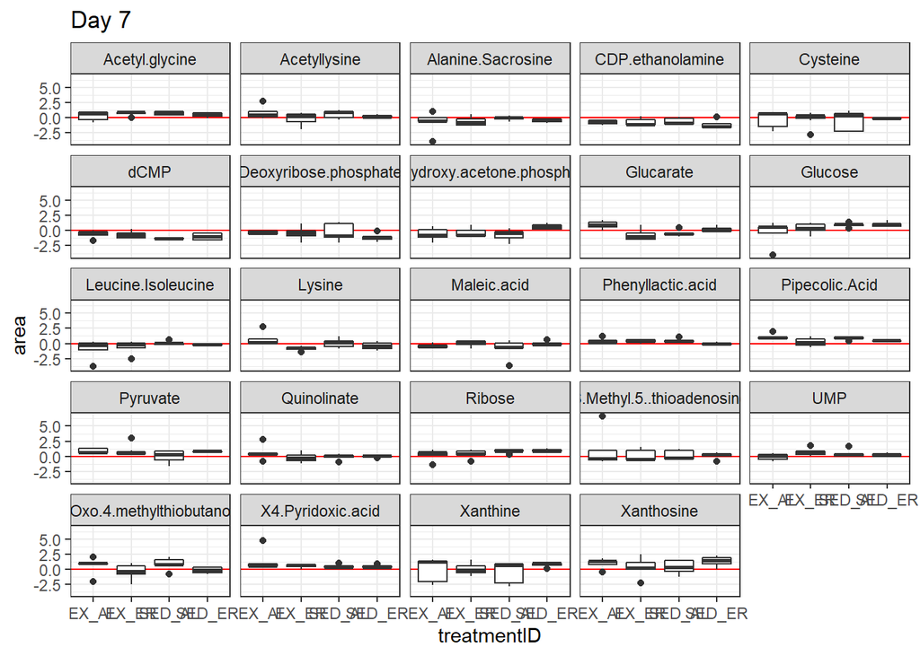

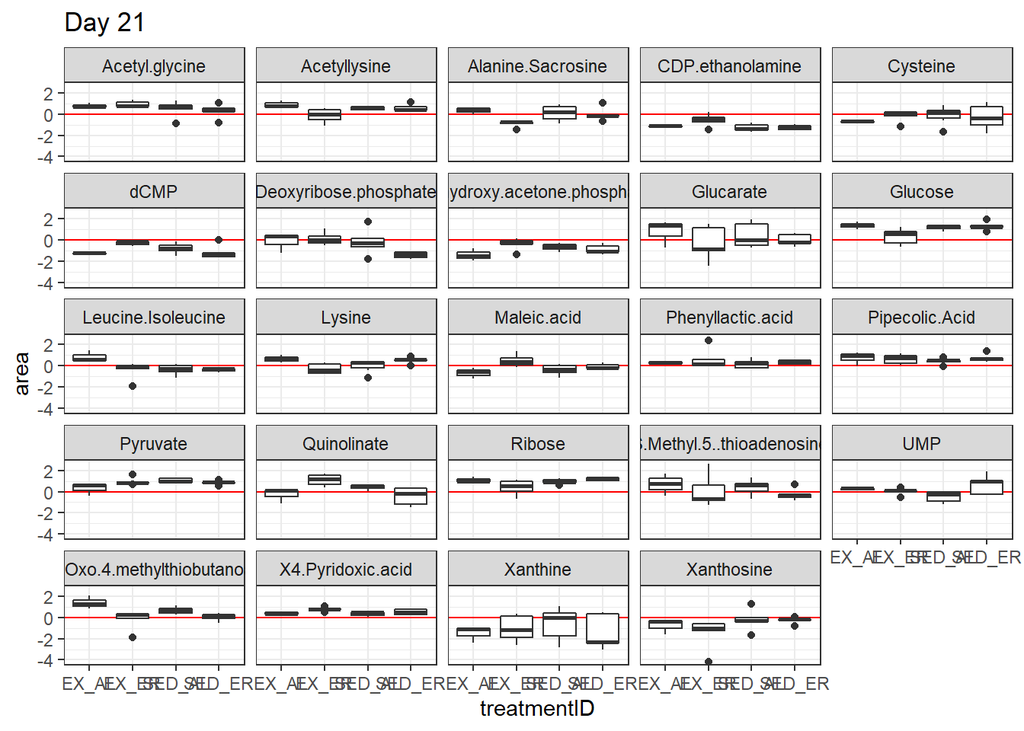

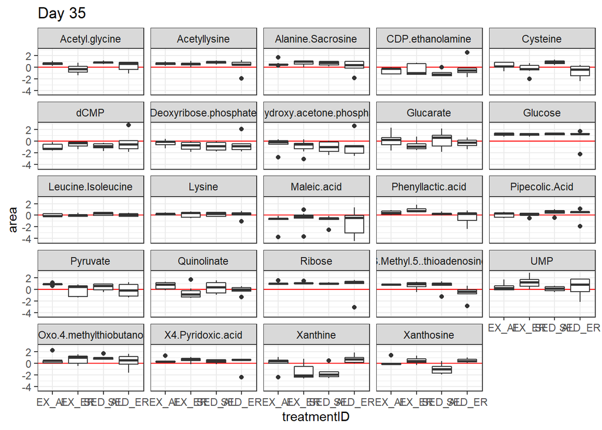

## Exercise vs. Sedentary

Two exercise groups: exercised and exercise-restricted (sedentary).

### Tumor

There is one significant metabolite: Quinolinate.

| metabolite | fStat | contrast | estimate | SE | df | t.ratio | p.value |
| --- | --- | --- | --- | --- | --- | --- | --- |
| Quinolinate | 5.2084 | EX - SED | -1.484028 | 0.65 | 19 | -2.282 | 0.034 |

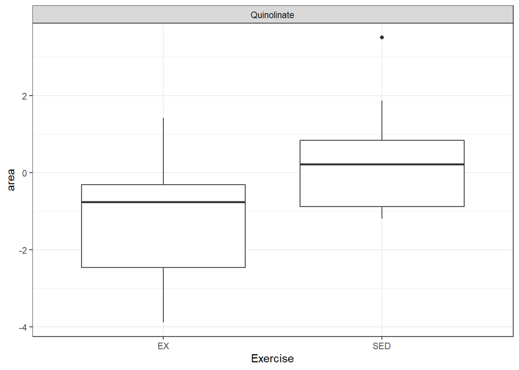

Quinolinate is higher in the Sedentary than Exercising group.

### Plasma

|  | metabolite | Time | fStat | contrast | estimate | SE | df | t.ratio | p.value |
| --- | --- | --- | --- | --- | --- | --- | --- | --- | --- |
| 3 | Phenyllactic.acid | D35 | 6.6334 | EX - SED | 0.7537822 | 0.293 | 22 | 2.576 | 0.017 |
| 2 | Xanthosine | D21 | 4.6654 | EX - SED | -0.9789703 | 0.453 | 17 | -2.160 | 0.045 |
| 1 | Fructose.1.6.bisphosphate | D7 | 6.4247 | EX - SED | -1.2389471 | 0.489 | 19 | -2.535 | 0.020 |
| 31 | ADP | D35 | 5.1057 | EX - SED | -0.8355132 | 0.370 | 22 | -2.260 | 0.034 |
| 21 | CDP.ethanolamine | D21 | 5.8079 | EX - SED | 0.4779519 | 0.198 | 17 | 2.410 | 0.028 |

| metabolite | EX mean | SED mean |
| --- | --- | --- |
| ADP | -0.871 | -0.336 |
| CDP.ethanolamine | -0.652 | -0.909 |
| Fructose.1.6.bisphosphate | -1.265 | -0.556 |
| Phenyllactic.acid | 0.550 | 0.153 |
| Xanthosine | 0.066 | 0.044 |

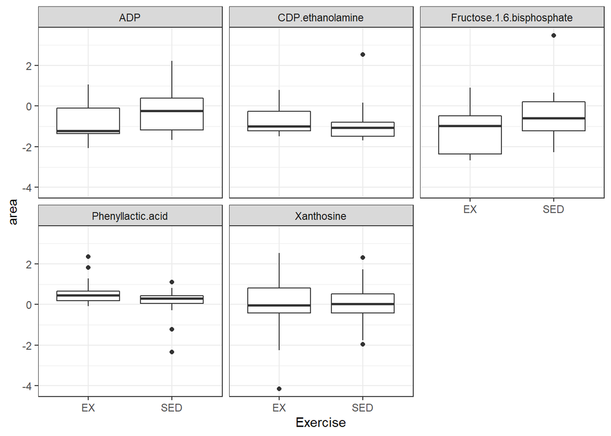

There are multiple significant metabolites between Exercise treatments in the plasma tissue, so these are difficult to visualize with boxplots.

## Weight Restricted vs Ad-lib Fed

Two weight groups: energy restricted and ad libitum fed

### Tumor

| metabolite | fStat | contrast | estimate | SE | df | t.ratio | p.value |
| --- | --- | --- | --- | --- | --- | --- | --- |
| Alanine.Sacrosine | 5.0834 | AL - ER | -0.6735539 | 0.299 | 19 | -2.255 | 0.036 |
| Acetyl.glycine | 7.6498 | AL - ER | 1.2268458 | 0.444 | 19 | 2.766 | 0.012 |
| Pipecolic.Acid | 9.1041 | AL - ER | 1.2640176 | 0.419 | 19 | 3.017 | 0.007 |
| Homocysteine.Methylcysteine | 6.3724 | AL - ER | 0.9377814 | 0.371 | 19 | 2.524 | 0.021 |
| Quinolinate | 8.5580 | AL - ER | 1.7666464 | 0.604 | 19 | 2.925 | 0.009 |
| Acetyl.aspartate | 6.8353 | AL - ER | -0.7307415 | 0.280 | 19 | -2.614 | 0.017 |
| Glucose | 14.8504 | AL - ER | 0.5659873 | 0.147 | 19 | 3.854 | 0.001 |
| X6.Phospho.D.gluconate | 6.7873 | AL - ER | 1.4204819 | 0.545 | 19 | 2.605 | 0.017 |
| Pantetheine | 7.9481 | AL - ER | -1.2969431 | 0.460 | 19 | -2.819 | 0.011 |
| X4.Phosphopantothenate | 5.9799 | AL - ER | -0.7565339 | 0.309 | 19 | -2.445 | 0.024 |
| ADP | 5.0108 | AL - ER | -1.2439139 | 0.556 | 19 | -2.238 | 0.037 |
| CDP.ethanolamine | 4.4310 | AL - ER | -0.8742820 | 0.415 | 19 | -2.105 | 0.049 |
| UTP | 4.7132 | AL - ER | 1.4141966 | 0.651 | 19 | 2.171 | 0.043 |

| metabolite | AL mean | ER mean |
| --- | --- | --- |
| Acetyl.aspartate | 0.909 | 1.640 |
| Acetyl.glycine | -0.817 | -2.044 |
| ADP | 1.188 | 2.432 |
| Alanine.Sacrosine | -0.350 | 0.324 |
| CDP.ethanolamine | 1.920 | 2.794 |
| Glucose | -2.326 | -2.892 |
| Homocysteine.Methylcysteine | -1.310 | -2.248 |
| Pantetheine | 1.224 | 2.521 |
| Pipecolic.Acid | -0.787 | -2.051 |
| Quinolinate | 0.615 | -1.151 |
| UTP | -1.513 | -2.927 |
| X4.Phosphopantothenate | 0.561 | 1.318 |
| X6.Phospho.D.gluconate | 0.382 | -1.039 |

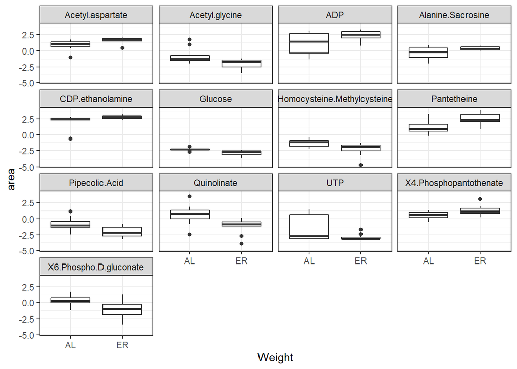

### Plasma

|  | metabolite | Time | fStat | contrast | estimate | SE | df | t.ratio | p.value |
| --- | --- | --- | --- | --- | --- | --- | --- | --- | --- |
| 3 | Pyruvate | D35 | 4.9126 | AL - ER | 0.7815017 | 0.353 | 22 | 2.216 | 0.037 |
| 2 | Alanine.Sacrosine | D21 | 4.9300 | AL - ER | 0.6541657 | 0.295 | 17 | 2.220 | 0.040 |
| 21 | Maleic.acid | D21 | 8.1603 | AL - ER | -0.6679699 | 0.234 | 17 | -2.857 | 0.011 |
| 31 | Acetyl.glycine | D35 | 9.6475 | AL - ER | 0.8324964 | 0.268 | 22 | 3.106 | 0.005 |
| 32 | Cysteine | D35 | 9.6733 | AL - ER | 1.0555557 | 0.339 | 22 | 3.110 | 0.005 |
| 1 | Pipecolic.Acid | D7 | 10.1045 | AL - ER | 0.6711611 | 0.211 | 19 | 3.179 | 0.005 |
| 11 | Hydroxyproline.Aminolevulinate | D7 | 6.4560 | AL - ER | 0.8119287 | 0.320 | 19 | 2.541 | 0.020 |
| 22 | Asparagine | D21 | 4.8794 | AL - ER | 0.9757582 | 0.442 | 17 | 2.209 | 0.041 |
| 23 | Ornithine | D21 | 4.5788 | AL - ER | 0.5422631 | 0.253 | 17 | 2.140 | 0.047 |
| 24 | Malate | D21 | 8.5994 | AL - ER | -0.4673966 | 0.159 | 17 | -2.932 | 0.009 |
| 25 | Alpha.ketoglutarate | D21 | 6.3883 | AL - ER | -0.6543332 | 0.259 | 17 | -2.528 | 0.022 |
| 12 | Lysine | D7 | 9.0431 | AL - ER | 1.0349451 | 0.344 | 19 | 3.007 | 0.007 |
| 26 | X2.Oxo.4.methylthiobutanoate | D21 | 11.2649 | AL - ER | 0.9654361 | 0.288 | 17 | 3.356 | 0.004 |
| 33 | Quinolinate | D35 | 5.0538 | AL - ER | 0.8294732 | 0.369 | 22 | 2.248 | 0.035 |
| 34 | Glyceraldehdye.3.phosphate | D35 | 4.4170 | AL - ER | -0.4656108 | 0.222 | 22 | -2.102 | 0.047 |
| 27 | Acetyl.aspartate | D21 | 5.0485 | AL - ER | -0.3511156 | 0.156 | 17 | -2.247 | 0.038 |
| 35 | Acetyl.aspartate | D35 | 7.6479 | AL - ER | -0.5732023 | 0.207 | 22 | -2.765 | 0.011 |
| 13 | N.Carbamoyl.L.aspartate | D7 | 7.2615 | AL - ER | -0.4232920 | 0.157 | 19 | -2.695 | 0.014 |
| 28 | X4.Pyridoxic.acid | D21 | 5.9614 | AL - ER | -0.2616544 | 0.107 | 17 | -2.442 | 0.026 |
| 29 | Pantothenate | D21 | 5.9733 | AL - ER | -0.2302161 | 0.094 | 17 | -2.444 | 0.026 |
| 36 | Deoxyuridine | D35 | 7.0119 | AL - ER | 0.5259068 | 0.199 | 22 | 2.648 | 0.015 |
| 37 | Glucosamine.1.6.phosphate | D35 | 4.9640 | AL - ER | -0.7465556 | 0.335 | 22 | -2.228 | 0.036 |
| 38 | Xanthosine | D35 | 9.4951 | AL - ER | -0.9306259 | 0.302 | 22 | -3.081 | 0.005 |
| 210 | CMP | D21 | 6.3314 | AL - ER | -1.0412333 | 0.414 | 17 | -2.516 | 0.022 |
| 14 | Trehalose.Sucrose | D7 | 7.0628 | AL - ER | -0.4873233 | 0.183 | 19 | -2.658 | 0.016 |
| 39 | UDP | D35 | 4.5791 | AL - ER | -0.6248976 | 0.292 | 22 | -2.140 | 0.044 |
| 15 | X5.Methyl.THF | D7 | 4.4664 | AL - ER | 0.8342548 | 0.395 | 19 | 2.113 | 0.048 |

| metabolite | AL mean | ER mean |
| --- | --- | --- |
| Acetyl.aspartate | -0.577 | -0.289 |
| Acetyl.glycine | 0.623 | 0.352 |
| Alanine.Sacrosine | 0.153 | -0.137 |
| Alpha.ketoglutarate | 0.490 | 0.857 |
| Asparagine | 0.254 | -0.185 |
| CMP | -0.728 | 0.121 |
| Cysteine | -0.006 | -0.290 |
| Deoxyuridine | 0.622 | 0.232 |
| Glucosamine.1.6.phosphate | -0.110 | -0.052 |
| Glyceraldehdye.3.phosphate | -0.375 | 0.000 |
| Hydroxyproline.Aminolevulinate | 0.458 | -0.156 |
| Lysine | 0.262 | -0.120 |
| Malate | -0.766 | -0.143 |
| Maleic.acid | -0.708 | -0.267 |
| N.Carbamoyl.L.aspartate | -0.730 | -0.494 |
| Ornithine | -0.085 | -0.248 |
| Pantothenate | -0.110 | 0.055 |
| Pipecolic.Acid | 0.607 | 0.360 |
| Pyruvate | 0.605 | 0.478 |
| Quinolinate | 0.324 | -0.094 |
| Trehalose.Sucrose | 0.572 | 0.944 |
| UDP | -0.701 | -0.477 |
| X2.Oxo.4.methylthiobutanoate | 0.821 | 0.105 |
| X4.Pyridoxic.acid | 0.595 | 0.529 |
| X5.Methyl.THF | 0.350 | 0.077 |
| Xanthosine | -0.060 | 0.157 |

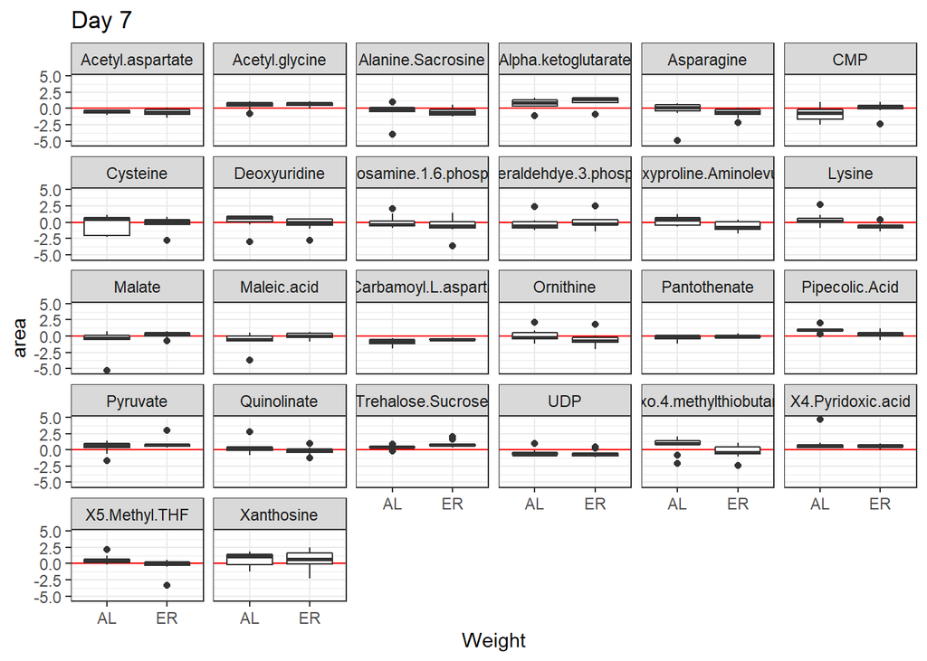

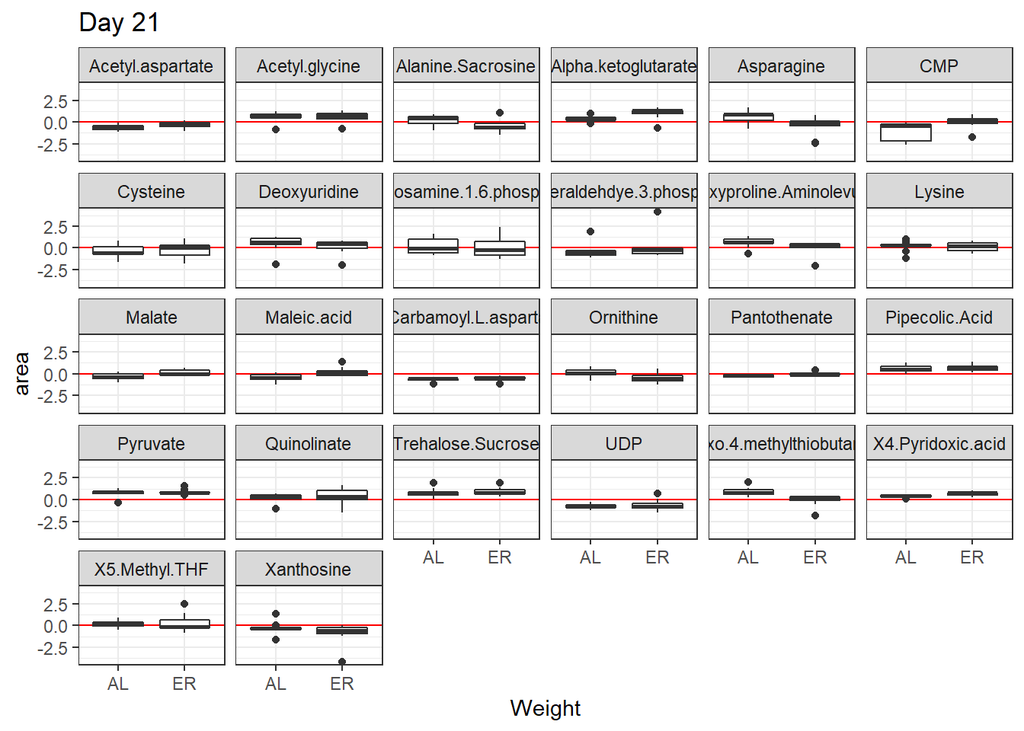

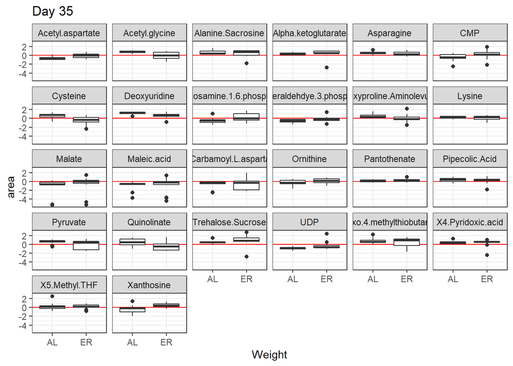